# Understanding 911 calls around UW

*This analysis adapte from [Walking the Beat: Mining Seattle’s Police Report Data](https://www.bayesimpact.org/stories/?name=walking-the-beat-mining-seattles-police-report-data) by Jeff Wong*

# 1. Including a few packages

# 2. Loading the data

```r
MGH_LONGITUDE = -122.307987
MGH_LATITUDE = 47.655038
# importing Data
PATH_DATA_MGH_TINY = paste(getwd(), "/data/Seattle_Police_Department_911_Incident_Response_Near_MGH_tiny.csv", sep = "")
if(file.exists(PATH_DATA_MGH_TINY)){
  data_mgh <- read.csv(PATH_DATA_MGH_TINY, header=T, sep=",")
} else {
  print("data file not found")
}
#adding columns to the data
data_mgh$at_scene_time_ts = as.POSIXct(strptime(data_mgh$At.Scene.Time, "%m/%d/%Y %I:%M:%S %p")) #converting time from String to date and time representation (POSIXct)
data_mgh$at_scene_time_hr = hour(ymd_hms(as.character(data_mgh$at_scene_time_ts)))
data_mgh$at_scene_time_date = as.Date(data_mgh$at_scene_time_ts)
# data$at_scene_time_week = floor(as.numeric(data_mgh$at_scene_time_date - min(data_mgh$at_scene_time_date, na.rm=TRUE)) / 7) + 1
data_mgh$event_clearance_ts = as.POSIXct(strptime(data_mgh$Event.Clearance.Date, "%m/%d/%Y %I:%M:%S %p"))
data_mgh$event_clearance_date = as.Date(data_mgh$event_clearance_ts)
data_mgh$event_clearance_hr = hour(ymd_hms(as.character(data_mgh$event_clearance_ts)))
data_mgh$time_until_event_clear = as.numeric(data_mgh$event_clearance_ts - data_mgh$at_scene_time_ts)
data_mgh$Initial.Type.Group = factor(data_mgh$Initial.Type.Group)
data_mgh$Event.Clearance.Group = factor(data_mgh$Event.Clearance.Group)
data_mgh$Zone.Beat = factor(data_mgh$Zone.Beat)
data_mgh$Latitude = round(data_mgh$Latitude, 3)
data_mgh$Longitude = round(data_mgh$Longitude, 3)
View(data_mgh)
```

# 3. Missing Data

Missing data can be a problem. If a large proportion of data is missing, we may end with results that are not representative of the population.

*TODO* There are 2 columns for date/time (at_scene_time_ts, event_clearance_ts). Figure out what proportion of reports have values. *hint*: Use the sum() and is.na() functions!

```r
total_reports = nrow(data_mgh)
total_reports
```

```
[1] 1744
```

```r
# write code below!
(total_reports - sum(is.na(data_mgh$at_scene_time_ts))) / total_reports
```

```
[1] 0.3056193
```

```r
(total_reports - sum(is.na(data_mgh$event_clearance_ts))) / total_reports
```

```
[1] 0.9925459
```

# 4. Frequency Tables

Frequency tables are a common way to analyze data. For example, Event.Clearance.Group tells you the type of crime that was reported. Each row in a frequency table would give you the number of reports for a certain type of crime. Let’s look at that frequency table.

The data.table package helps you create frequency tables in R. Run the first line to read the documentation on it.

```r
?data.table # read about what data.table does!
#Here, we use the table() method to create a frequency table for types of crime
freq_of_crimes <- table(data_mgh$Event.Clearance.Group)
# let's look at our frequency table!
View(freq_of_crimes)
```

# 5. Frequency of Crimes by Day of Week

Let’s do a quick sanity check of our data by looking at the number of reports by day of week. Because police services are available every day of the week, we would expect at least some reports occuring each day of the week. Run the code below to verify that.

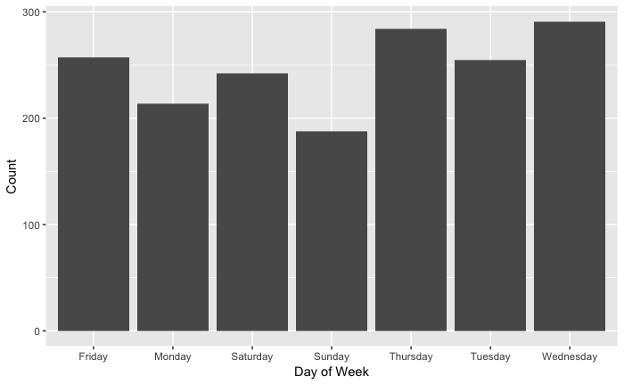

```r
# first, let's convert the dates we have (event_clerance_date, e.g. "07/19/2010 05:04:00 AM") to days of the week (e.g. "Monday")
# the weekdays() method does that for us
crimes_by_day_of_week <- weekdays(data_mgh$event_clearance_date)
# TODO: Create a frequency table of crimes by day of week
freq_crimes_by_dow <- table(crimes_by_day_of_week) #replace "data.frame()" with your code!
# Now let's look at the frequency table!
View(freq_crimes_by_dow)
# Now let's plot this data. We haven't covered plotting too much, so be sure to ask questions about what's going on here!
ggplot(as.data.frame(freq_crimes_by_dow), #ggplot can't take in data.tables, so we have to convert it back to a dataframe
       aes(x = crimes_by_day_of_week, y = Freq)) +
  geom_bar(stat = 'identity') + # create bar plot
  xlab ("Day of Week") + ylab("Count") #labeling axis
```

# 6. Frequency of Crimes by Time of Day

Perhaps we should have more officers patroling during times of day which are high crime. *TODO* Plot the number of reported incidents by hour of day and see what suggestions you may make.

*hint* this code should look similar to the previous block (Frequency of Crimes by Day of Week). *challenge*: Crime by time of day may vary by weekend days and weekdays. Plot the crime by times of day for weekdays and weekend days separately.

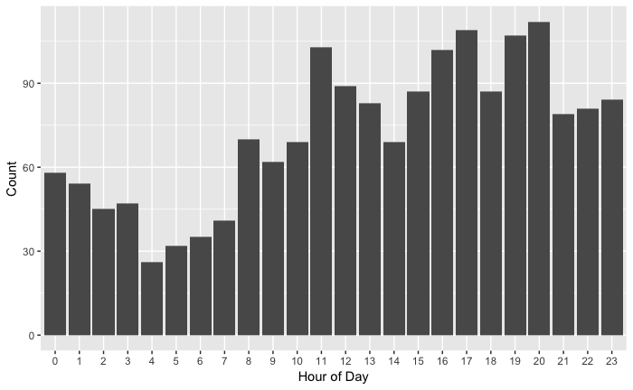

```r
# Your code below!
freq_crimes_by_hour <- table(data_mgh$event_clearance_hr)
View(freq_crimes_by_hour)
ggplot(as.data.frame(freq_crimes_by_hour),
       aes(x = Var1, y=Freq)) +
  geom_bar(stat = 'identity') +
  xlab("Hour of Day") + ylab("Count")
```

# 7. Types of contacts

Not all crime is the same! Let’s see the frequency of each type of crime (Event.Clearance.Group). Generate a plot of each type of crime.

[figure not shown]

# 8. Digging deeper in the type of event

There are a lot of “Disturbances” and “Suspicious Circumstances” reported, but what does that mean? The “Event.Clearance.Description” field may provide more information.

*TODO*: For all crimes which are labeled as “Disturbances”, create a frequency table of the descriptions of crimes which are disturbances (Initial.Type.Group) *hint*: Filter the data by “Event.Clearance.Group” *challenge*: Do the same analysis for the “Suspicious Circumstances” group.

```r
#TODO
disturbances <- data_mgh %>% filter(Event.Clearance.Group == "DISTURBANCES")
unique(disturbances$Event.Clearance.Group) # make sure our filter worked
```

```
[1] DISTURBANCES
39 Levels:  ACCIDENT INVESTIGATION ANIMAL COMPLAINTS ARREST ASSAULTS AUTO THEFTS BEHAVIORAL HEALTH BIKE BURGLARY CAR PROWL DISTURBANCES FALSE ALACAD FALSE ALARMS FRAUD CALLS HARBOR CALLS ... WEAPONS CALLS
```

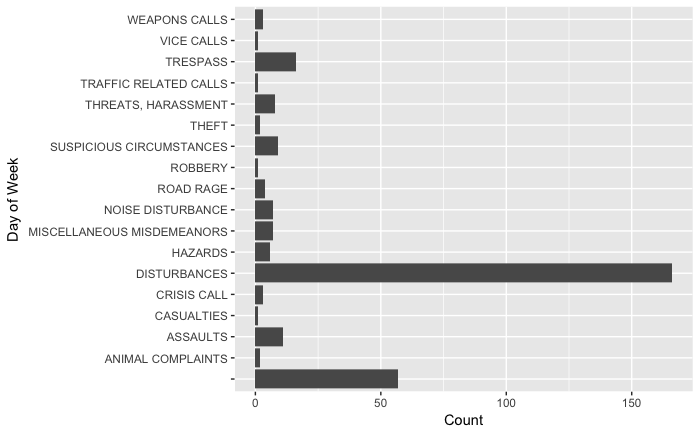

```r
freq_dist <- table(disturbances$Initial.Type.Group)
View(freq_dist) # inspect data and see a few groups have 0 occurences. let's filter them out!
freq_dist <- filter(as.data.frame(freq_dist), Freq>0)
# plot data. apparently these categorizations are a bit noisy!
ggplot(freq_dist,
       aes(x = Var1, y = Freq)) +
  geom_bar(stat = 'identity') + # create bar plot
  xlab ("Day of Week") + ylab("Count") + #labeling axis
  coord_flip()
```